# Malle ERW Bayesian Treatment Comparison Plots

Plots regenerated from existing Bayesian posterior contrasts

Bayesian regression models were fitted separately for each soil physicochemical, mineralogical, aggregate stability, carbon and radiocarbon response variable using Stan via the cmdstanr package in R. Treatment-specific location parameters were estimated using a Student-t likelihood (with four degrees of freedom), with standardized response variables modelled as a function of treatment. Regularizing normal priors (μ ~ Normal(0, 1)) were assigned to treatment-specific parameters, while a half-Student-t prior was used for the residual standard deviation. Posterior distributions were estimated using four Markov chain Monte Carlo chains, with 2,000 warm-up and 2,000 sampling iterations per chain. Treatment effects were evaluated through posterior contrasts, calculated as differences between treatment-specific posterior estimates. Primary contrasts compared each amendment treatment (lime, Hühnerberg, Eifelgold and Bolsdorfer at 50 t ha⁻¹) against the untreated control. Posterior median differences and 95% credible intervals were calculated in both standardized and original measurement units. The posterior probability of a positive or negative treatment effect was determined as the proportion of posterior draws in which the corresponding treatment-control contrast was greater or less than zero, respectively. No statistical comparisons were conducted for dose-response experiment (no replicates).

## 1 Results

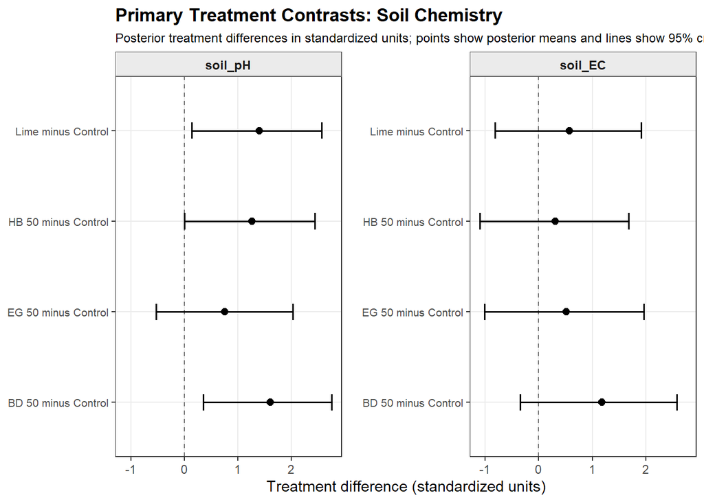

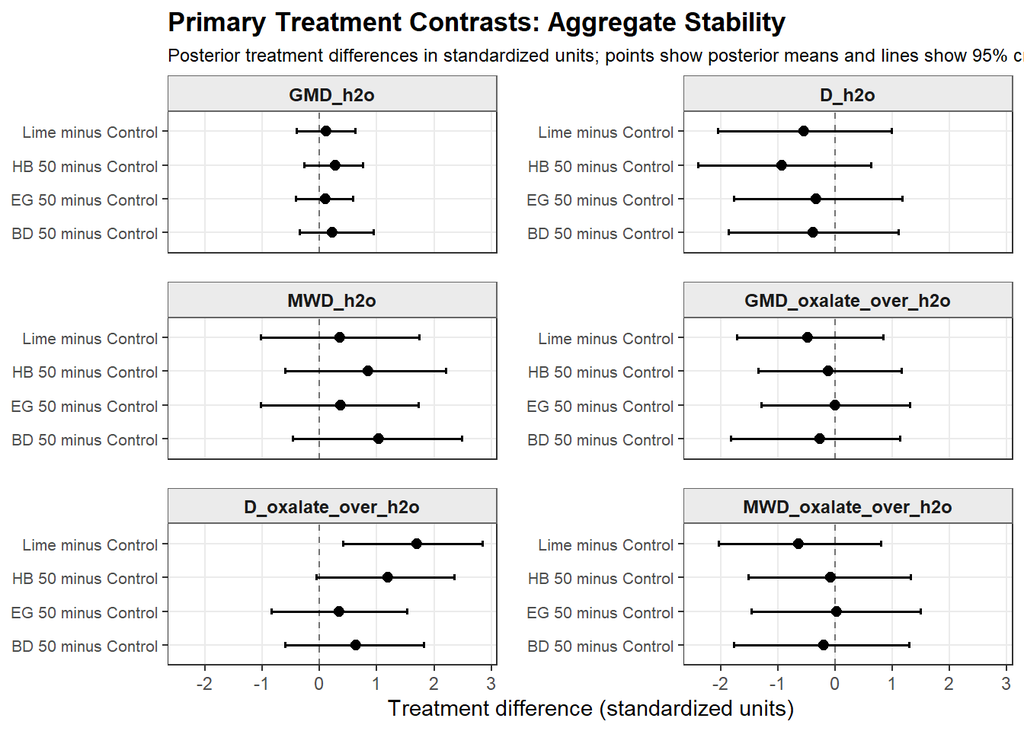

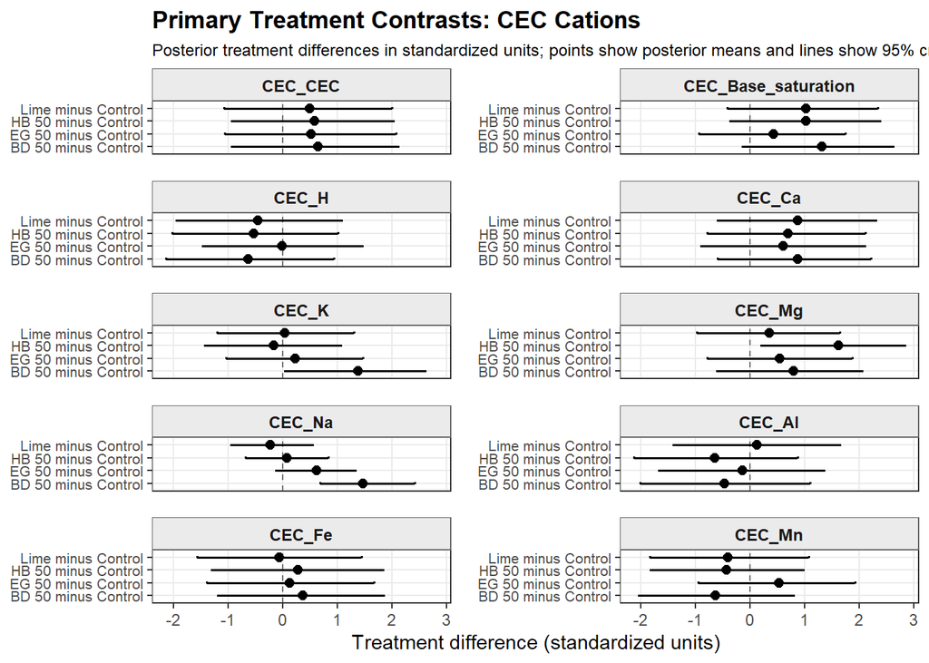

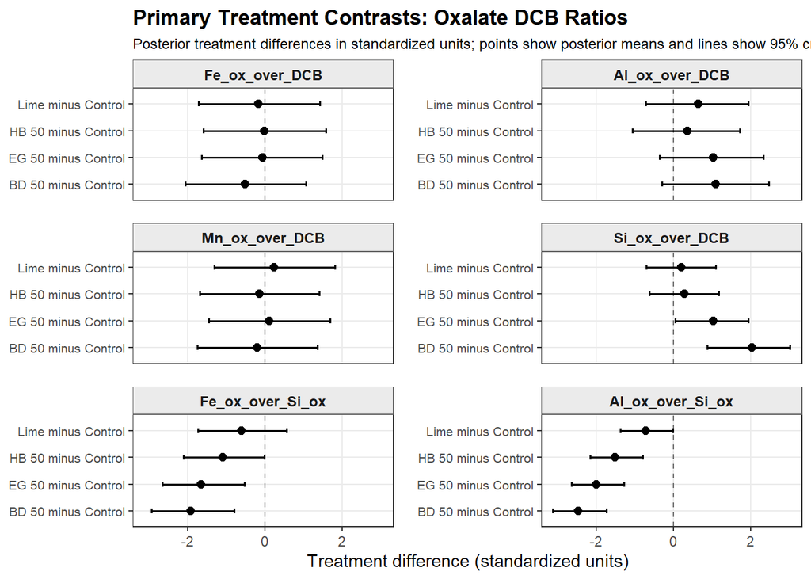

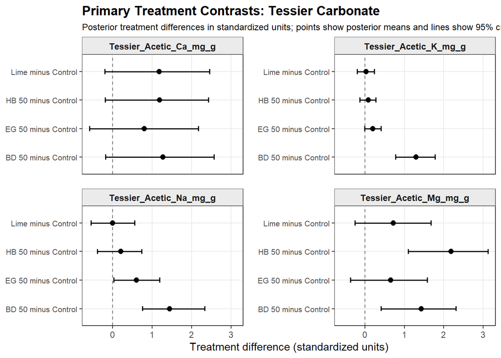

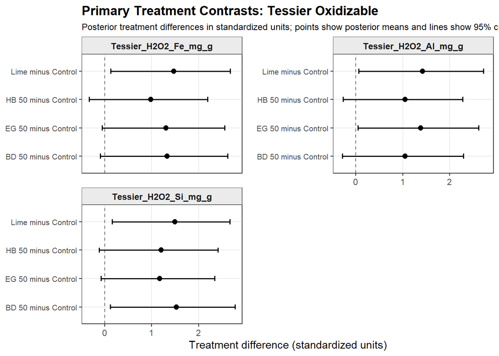

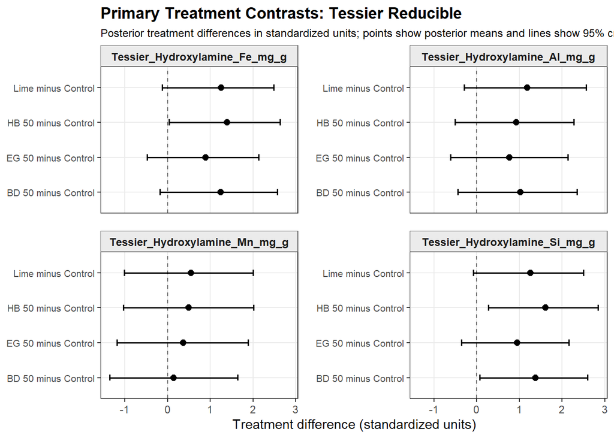

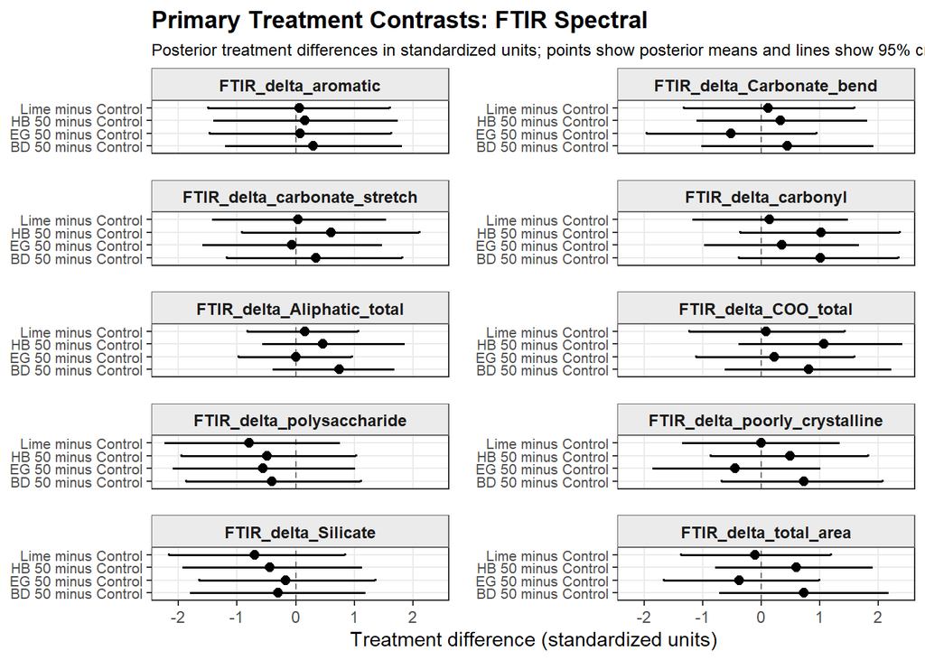

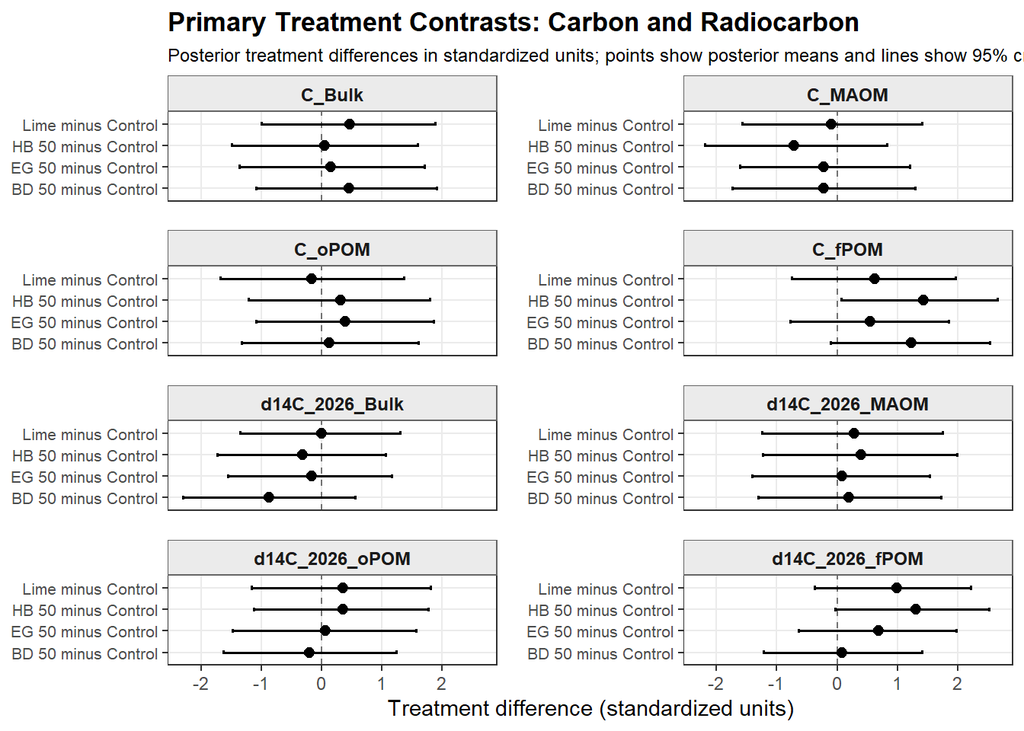

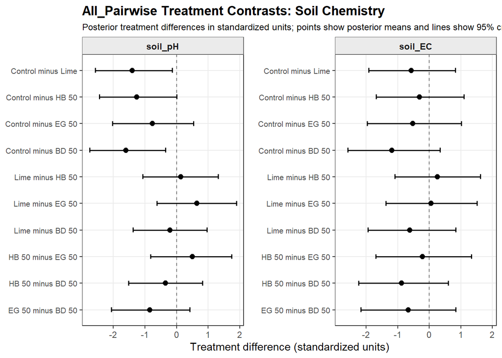

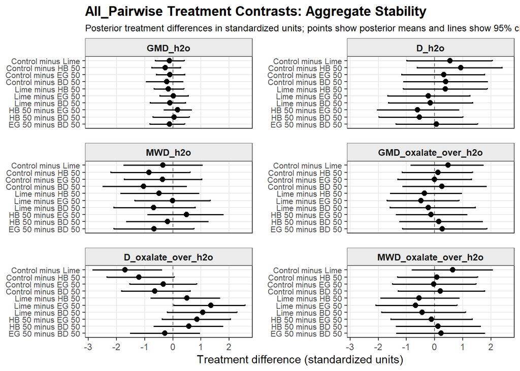

[figure not shown]

[24 more figures not shown]